# Neural Machine Translator

## Loading the preprocessed data

```python
import logging
import os
import numpy as np
from utils import load_obj

logging.getLogger("tensorflow").setLevel(logging.WARNING)
os.environ['TF_CPP_MIN_LOG_LEVEL'] = '3'

import tensorflow as tf
tf.logging.set_verbosity(tf.logging.ERROR)
logging.basicConfig(level=logging.DEBUG, filename="logfile", filemode="a+",
                        format="%(asctime)-15s %(levelname)-8s %(message)s")
os.environ['TF_CPP_MIN_LOG_LEVEL'] = '3'
lang_t = 'en'
lang_s = 'fr'
prep_path = "/DATA/"

data_path = ""
data_dict = load_obj(prep_path+'data_dic')
s_train = data_dict["s_train"] # preprocessed data
t_train = data_dict["t_train"]
s_test = data_dict["s_test"]
t_test = data_dict["t_test"]
word2id_s = data_dict["word2id_s"] # word-to-ID dictionaries
word2id_t = data_dict["word2id_t"]
id2word_s = data_dict["id2word_s"]
id2word_t = data_dict["id2word_t"]

vocab_size_t = len(word2id_t.keys()) # Includes UNK, EOS and PAD tokens
vocab_size_s = len(word2id_s.keys())

raw_s_test = load_obj(prep_path+"source_test") # Data for benchmark model
raw_t_test = load_obj(prep_path+"target_test") # Data for benchmark model
print "Tokens in s_train are of type ", type(s_test[0][0])
print "Tokens in raw_s_train are of type ", type(raw_s_test[0][0])
print "s_test and raw_s_test are the same length? : ", len(s_test) == len(raw_s_test)
print len(s_test),  len(raw_s_test)
```

```
Tokens in s_train are of type  <type 'int'>
Tokens in raw_s_train are of type  <type 'unicode'>
s_test and raw_s_test are the same length? :  True
17742 17742
```

## Benchmark model

Here I use the GoogleTrans python package to translate the corpus by translating each individual word in the text. There seems to be an issue with the number of JSON requests the model makes to the Google Translate service, so it needs to work in passes. If a phrase is skipped due to a JSON error, keep it stored and try again later (with a new Translator instance).

```python
from googletrans import Translator


def googletrans_pass(s_text, target_lang='fr'):
    """ This function makes a single pass through the data and tries to
    translate each phrase one word at a time. Occasionally there are JSON
    errors, probably due to too many requests being made. In this case
    a new Translator instance is made and the failed attempts/skipped phrases
    are returned, to be attempted again.
    """
    translator = Translator()
    trans_corpus = []
    skipped_phrases = []
    for i, phrase in s_text:
        try:
            trans_corpus.append((i, [trans.text for
                                trans in translator.translate(
                                phrase, dest=target_lang)]))
        except ValueError as err:
            # Making a new Translator instance seems to help JSON errors
            translator = Translator()
            skipped_phrases.append((i, phrase))
            print "{} for phrase {}".format(err, i)
    return trans_corpus, skipped_phrases

def translate_word_by_word(source_text):
    # Need to keep track of phrase ordering by labelling
    source_text = [(i, phr) for i, phr in enumerate(source_text)]
    trans_text, skipped_phrases = googletrans_pass(source_text, target_lang=lang_t)
    print "There are {} phrases which could not be translated first time around.".format(
                                                                    len(skipped_phrases))
    # Keep making passes until there are no more untranslated phrases left
    j = 2
    while len(skipped_phrases)>0:
        translated_corpus = []
        tc_s, skipped_phrases = googletrans_pass(skipped_phrases, target_lang=lang_t)
        trans_text += tc_s
        print "There are {} phrases which could not be translated in pass {}.".format(
                                                            len(skipped_phrases), j)
        j+=1
    # Sort the phrases via their labels.
    # Sorted function gives ([indices], [phrases]) so just need 2nd element
    trans_text = zip(*sorted(zip(*BM_translated)))[1]
    return trans_text

# Takes a while to run, running this cell is not for the faint hearted
BM_translated = translate_word_by_word(raw_s_test)
print "Corpus translated from {} to {}".format(lang_s, lang_t)
save_obj(BM_translated, "BM_translated")
```

```
No JSON object could be decoded for phrase 320
No JSON object could be decoded for phrase 682
No JSON object could be decoded for phrase 1047
No JSON object could be decoded for phrase 1141
```

[output not shown]

[output cut: 74 more lines]

[output not shown]

## Evaluation metric: BLEU Score

Here I use the NLTK implementation of BLEU score to measure how successful the machine translation was.

```python
from nltk.translate import bleu_score
from utils import remove_EOS_PAD

p_phrase1 = [4,5,4,5,4,5, 1, 0]
t_phrase = [4,5,6,34,8,76, 87, 1]
# Truncate sequences at [1]
t_phrase = remove_EOS_PAD(t_phrase)
p_phrase1 = remove_EOS_PAD(p_phrase1)

print "BLEU1 score test is {}.".format(
    bleu_score.corpus_bleu([[t_phrase]], [p_phrase1], weights=([1])))
print "BLEU2 score test is {}.".format(
    bleu_score.corpus_bleu([[t_phrase]], [p_phrase1], weights=([0.5,0.5])))
```

```
BLEU1 score test is 0.282160574964.
BLEU2 score test is 0.218560641558.
```

```python
#test_targets = [[ids_to_phrases(phrase,id_to_word_t)]for phrase in test_t]

BM_BLEU4 = bleu_score.corpus_bleu(test_targets, BM_translated, weights=(
                                                            0.25,0.25, 0.25,0.25))
BM_BLEU2 = bleu_score.corpus_bleu(test_targets, BM_translated, weights=(0.5,0.5))
BM_BLEU1 = bleu_score.corpus_bleu(test_targets, BM_translated, weights=([1]))

print "Actual: \n", (" ".join(test_targets[10])).encode('utf-8')
print "Prediction: \n", (" ".join(BM_translated_corp[10])).encode('utf-8')
print "Unigram BLEU score is {}.".format(BM_BLEU1)
print "Bigram BLEU score is {}.".format(BM_BLEU2)
print "4-Gram BLEU: {}".format(BM_BLEU4)
```

[output not shown]

# The Neural Network

For development reasons I will use a much smaller dataset, using only 10% of the available data to test functionality.

```python
testing_only = False
load_embeddings = False # Do we want to load in the embeddings?
plot_name = ''
feed_previous_probability = 0.7
anneal_feed_previous = False
encoder_hidden_units = 512
epochs =  45 # How many times we loop over the whole training data

GPU = True

prepend = "short_nmt/"
device_1 = "gpu:0"
device_2 = device_1
data_path =prep_path
if not GPU:
    #prepend = ''

    device_1 = "cpu:0"
    device_1 = "cpu:1"
    data_path = "DATA/"


#dev_fraction = 0.1
#test_fraction = 0.05

log_dir = prepend+plot_name
logging.basicConfig(level=logging.DEBUG, filename=prepend+'logfile'+plot_name, filemode="a+",
                        format="%(asctime)-15s %(levelname)-8s %(message)s")
```

## Loading pretrained embeddings

Go through each word in the vocabulary and find the pretrained word embedding in the polyglot pickle file. If one doesn't exist, initialise to a random distribution.

```python
import pickle

def get_embeddings(id_to_word, lang):
    # We load pretrained word2vec embeddings from polyglot to save on training time
    filename =data_path+'polyglot-'+lang+'.pkl'
    pretrain_vocab, pretrain_embed = pickle.load(open(filename, 'rb'))
    # Embeddings for <PAD> and <EOS> already exist  - find them first
    embed_vocab = [pretrain_embed[pretrain_vocab.index('<PAD>')], pretrain_embed[pretrain_vocab.index('</S>')]]
    skip_count = 0
    skipped_words = []
    metadata = u'<PAD>\n<EOS>\n' # For tensorboard embeddings
    for idx, word in sorted(id_to_word.items()[2::]):
        metadata += word+r"\n"
        try:
            pretrain_idx = pretrain_vocab.index(word)
            embed_vocab.append(pretrain_embed[pretrain_idx])
        except ValueError:
            try:
                # it could be that the word is a name which needs to
                # be capitalized. Try this...
                pretrain_idx = pretrain_vocab.index(str(word.title()))
                embed_vocab.append(pretrain_embed[pretrain_idx])
            except ValueError:
                try:
                    # it could be that the word is an achronym which needs to
                    # be upper case. Try this...
                    pretrain_idx = pretrain_vocab.index(word.upper())
                    embed_vocab.append(pretrain_embed[pretrain_idx])
                except ValueError:
                    # Give up trying to find an embedding.
                    # How many words are skipped? Which ones?
                    skip_count +=1
                    skipped_words.append(word)
                    # Let's just initialise the embedding to a random normal distribution
                    embed_vocab.append(np.random.normal(loc=0.0, scale=np.sqrt(2)/5, size=64))

    embed_vocab = np.array(embed_vocab, dtype=np.float32)
    print "The embedding matrix for {} has {} columns and {} rows.".format(lang,
                                                embed_vocab.shape[0], embed_vocab.shape[1])
    print "{} vocab words were not in the {} embeddings file.".format(skip_count, lang)
    return embed_vocab, skipped_words, metadata
```

```python
def variable_summaries(var):
  """Attach a lot of summaries to a Tensor (for TensorBoard visualization).
  I'll just get as much data as I can."""
  with tf.name_scope('summaries'):
    mean = tf.reduce_mean(var)
    tf.summary.scalar('mean', mean)
    with tf.name_scope('stddev'):
      stddev = tf.sqrt(tf.reduce_mean(tf.square(var - mean)))
    tf.summary.scalar('stddev', stddev)
    tf.summary.scalar('max', tf.reduce_max(var))
    tf.summary.scalar('min', tf.reduce_min(var))
    tf.summary.histogram('histogram', var)
```

```python
# the ith word in words corresponds to the ith embedding
embed_vocab_s = np.array(np.random.normal(loc=0.0, scale=np.sqrt(2)/5, size=(vocab_size_s, 64)), dtype=np.float32)
embed_vocab_t = np.array(np.random.normal(loc=0.0, scale=np.sqrt(2)/5, size=(vocab_size_t, 64)), dtype=np.float32)
metadata_s = ''
metadata_t = ''
# We only want to load in the embeddings, running this with test_only=True
# takes a while with the full dataset

if load_embeddings:
    embed_vocab_s, skipped_s, metadata_s = get_embeddings(id2word_s, lang=lang_s)
    embed_vocab_t, skipped_t, metadata_t = get_embeddings(id2word_t, lang=lang_t)

tf.reset_default_graph()

with tf.device(device_1):
    with tf.name_scope("source_embeddings"):
        # Load encoder embeddings into trainable tensors
        source_embeddings = tf.Variable(embed_vocab_s, trainable=True, name="source_embeddings")
        variable_summaries(source_embeddings)
    with tf.name_scope("target_embeddings"):
        # Load decoder embeddings into trainable tensors
        target_embeddings = tf.Variable(embed_vocab_t, trainable=True, name="target_embeddings")
        variable_summaries(target_embeddings)
```

## Building the encoder layer

With each forward pass a batch of phrases is fed through the neural network, one word at a time, so for the purposes of building the sequence-to-sequence model it helps to think of just a single batch. The encoder inputs are going to be in the form of a tensor filled with word indices, of dimension `(encoder_max_time, batch size)` where maximum time is the length of the longest sequence in the batch. The batch size (though unusual) and maximum time step can change between batches so can be designated as `None` in the Tensorflow placeholder dimension. Similarly, the decoder inputs are of dimension `(decoder_max_time, batch_size)` where `decoder_max_time` does not need to equal `encoder_max_time` but must be the dimension of both the inputs and targets of the decoder. This is because at each timestep during training we must assess the quality of a single output slice (in time) of the decoder given a decoder input slice and some target sequence, therefore there must be valid tokens to compare at each time-step. If an output sequence is shorter than the target it is padded with zeros until it is the same length. Time will run down the columns of the input matrices which is called "time-major" format.

```python
with tf.device(device_1):
    with tf.name_scope('encoder_inputs'):
        encoder_inputs = tf.placeholder(shape=(None, None), dtype=tf.int32, name='encoder_inputs')
        encoder_inputs_length = tf.placeholder(shape=(None,), dtype=tf.int32, name='encoder_inputs_length')


    with tf.name_scope('decoder_targets'):
        decoder_targets = tf.placeholder(shape=(None, None), dtype=tf.int32, name='decoder_targets')
    with tf.name_scope('decoder_inputs'):
        decoder_inputs = tf.placeholder(shape=(None, None), dtype=tf.int32, name='decoder_inputs')
```

Next we find the embeddings which correspond to the words at each timestep. The words which were previously index integers for each sample in a batch/timestep, are used to index the columns of an embedding matrix. Using these column vectors as representations of the words means that the input matrices become tensors of dimension `(max_time_step, batch_size, embedding_hidden_dimension)'.

```python
with tf.device(device_1):
    with tf.name_scope('encoder_inputs_embed'):
        encoder_inputs_embedded = tf.nn.embedding_lookup(source_embeddings,
                                                encoder_inputs, name='encoder_inputs_embed')
    with tf.name_scope('decoder_inputs_embed'):
        decoder_inputs_embedded = tf.nn.embedding_lookup(target_embeddings,
                                                decoder_inputs, name='decoder_inputs_embed')
```

Now the encoder RNN is finally constructed, using an LSTM which is unrolled over the encoder time-steps dynamically using `tf.nn.dynamic_rnn`. Notive that the keyword argument `time_major = True` accounts for the fact that time-steps were defined along the columns of the input matrices.

The encoder RNN returns the encoder outputs - which are not used at all in sequence-to-sequence learning - and the final hidden state. This hidden state eventually becomes the first hidden state of the decoder layer.

```python
with tf.device(device_1):
    with tf.name_scope('encoder_rnn'):
        encoder_cell = tf.contrib.rnn.LSTMCell(encoder_hidden_units)

        encoder_outputs, encoder_final_state = tf.nn.dynamic_rnn(encoder_cell,
                                        encoder_inputs_embedded, dtype=tf.float32,
                                        time_major=True, scope='encoder_rnn')
        variable_summaries(encoder_outputs)
        variable_summaries(encoder_final_state)
```

```python
decoder_hidden_units = encoder_hidden_units # Set these to be the same at the moment
```

## The decoder layer: `raw_rnn`

Now for the subtle part. Ideally we would like to have control over precisely what the decoder inputs are at each time-step, however `dynamic_rnn` has a relatively constrained API, so all inputs must be specified at the initial time-step. This means that we cannot feed tokens generated at the current time-step in as inputs in the next timestep. This actually makes it impossible to make adequate precictions with the model, since a generative model must *see* the data it has produced in order to react accordingly, in real-time. In order to implement this, I define a *loop function* for a `raw_rnn` which replicates the functionality of `dynamic_rnn`, which allowing for the feeding of previously generated tokens into the decoder inputs. I also allow the user to define a probability with which the previously generated tokens are mixed in with the "ground truth" target data, so that the model can be conditioned on a statistical mixture of both inputs. Since the length of the decoder max timesteps is unknown at the beginning of training, this has to be defined somehow so I just set it to the length of the encoder inputs plus some extra timesteps to allow for some error. This could be set to the decoder targets but strictly speaking this length would not be known in a blind test.

```python
reverse_encoder_inputs = True
additional_decode_steps = 3 # Includes the extra step for the leading EOS token


with tf.device(device_2):
    encoder_max_time, batch_size = tf.unstack(tf.shape(encoder_inputs))
    decoder_lengths = encoder_inputs_length + additional_decode_steps
    # This is the projection layer, needed at every timestep because there is a possibility
    # of feeding previous tokens in.
    W = tf.Variable(tf.random_uniform([decoder_hidden_units, vocab_size_t], -1, 1), dtype=tf.float32)
    #bias
    b = tf.Variable(tf.zeros([vocab_size_t]), dtype=tf.float32)

    # The probability that we feed previous tokens in as decoder inputs
    # 0 = use ground truth training examples as inputs
    feed_previous_prob = tf.placeholder(tf.float32, shape=(), name='feed_previous_prob')

    # Create a slice in time of PAD - for padding entire batch once all the sequences have
    # terminated. Also slice for EOS which is used to initialise the loop_function
    eos_time_slice = tf.ones([batch_size], dtype=tf.int32, name='EOS')
    pad_time_slice = tf.zeros([batch_size], dtype=tf.int32, name='PAD')

    #retrieves columns of the embedding matrix. Dim= (batch_size, hidden_dim)
    eos_step_embedded = tf.nn.embedding_lookup(embed_vocab_t, eos_time_slice)
    pad_step_embedded = tf.nn.embedding_lookup(embed_vocab_t, pad_time_slice)
```

The loop function tells the RNN what to do and which quantities to manipulate at each timestep. If the model is feeding previously generated tokens in as decoder inputs it will have to pass the RNN output through a linear layer and find the argmax. Intially the hidden state will be set to the final state of the encoder and the initial input will be the `<EOS>` token. These are then mapped onto the inputs for the next timestep within `loop_fn`.

```python
with tf.device(device_2):
    def loop_fn_initial():
        initial_elements_finished = (0 >= decoder_lengths)  # Returns false unless something is wrong

        initial_input = eos_step_embedded
        # Self explanatory...
        initial_cell_state = encoder_final_state
        # Not sure what these
        initial_cell_output = None
        #none
        initial_loop_state = None  # we don't need to pass any additional information
        return (initial_elements_finished, # Boolean
                initial_input, # EOS
                initial_cell_state, # encoder state
                initial_cell_output, # The output to store for this state
                initial_loop_state)

    def loop_fn_transition(time, previous_output, previous_state, previous_loop_state):
        # What to do when moving from one time-step to the next
        def feed_previous():
             # We take the previous output word vectors and apply the linear layer
             # to each output word in the batch
            output_logits = tf.add(tf.matmul(previous_output, W), b)
            # Greedily gives the index of the word with the highest probability
            prediction = tf.argmax(output_logits, axis=1)
            # Find embedding for the predicted word
            return tf.nn.embedding_lookup(source_embeddings, prediction)

        def feed_ground_truth():
            # Find the current word in the shifted ground truth decoder targets
            # At initialisation, time=0. Therefore, decoder inputs are passed
            # here with a leading <EOS> token as usual.
            ground_truth = tf.gather(decoder_inputs, time)
            return tf.nn.embedding_lookup(target_embeddings, ground_truth)

        def get_next_input():
            # if uniform random number < fpp, feed_previous. If not feed decoder target.
            return tf.cond(tf.constant(np.random.uniform())<feed_previous_prob,
                            feed_previous, feed_ground_truth)

        # boolean tensor of [batch_size] indicating if all of the sequences have finished
        sequences_finished = (time >= decoder_lengths)
        #Computes the "logical and" of elements to produce scalar
        finished = tf.reduce_all(sequences_finished)
        # If sequences are finished PAD, if not get next input
        input = tf.cond(finished, lambda: pad_step_embedded, get_next_input)

        # states and outputs are passed through
        state = previous_state
        output = previous_output
        loop_state = None

        return (sequences_finished,
                input,
                state,
                output,
                loop_state)

    def loop_fn(time, previous_output, previous_state, previous_loop_state):
        if previous_state is None:    # time == 0
            assert previous_output is None and previous_state is None
            return loop_fn_initial()
        else:
            # time >0
            return loop_fn_transition(time, previous_output, previous_state, previous_loop_state)
```

Now the loop function has been defined, we can create the `raw_rnn`. Within the loop function we found word predictions at each timestep, which required projecting onto the vocabulary space to find a word (embedding).

```python
with tf.device(device_2):
    with tf.name_scope('decoder_rnn'):
        decoder_cell = tf.contrib.rnn.LSTMCell(decoder_hidden_units)
        decoder_outputs_, decoder_final_state, _ = tf.nn.raw_rnn(decoder_cell, loop_fn, scope='decoder_rnn')
        # Turn the output matrices dims=(batch_size, dec_hidden_layer_dim)
        # at each timestep into a tensor
        decoder_outputs = decoder_outputs_.stack()
        variable_summaries(decoder_outputs)
        variable_summaries(decoder_final_state)
```

## Forward and backward steps

In the previous cell, outputs from the `raw_rnn` were seen to form a tensor of dimension `(max_decoder_time, batch_size, dec_hidden_dim` since the outputs are for each sequence in the batch at each timestep are word embeddings. These need to be turned into sequences of word IDs, so in order to do so we flatten the tensor to have dimension `(max_decoder_time*batch_size, hidden_dim)` so it can be passed through the projection layer to discriminate which word it respresents, ending up with dimension `(max_decoder_time*batch_size, vocab_site_t)`. Then after reshaping this to a tensor of shape `(max_decoder_time, batch_size, vocab_site_t)` gives us the logits/scores for each word and an argmax is performed over the vocabulary words to generate the predictions. Note it is not necessary to perform softmax because the this function preserves ordering of the elements, so `max(softmax(v)) = max(v)`.

```python
with tf.device(device_2):
    with tf.name_scope('projection_layer'):
        # Get dimension information for the batch
        decoder_max_steps, decoder_batch_size, decoder_dim = tf.unstack(tf.shape(decoder_outputs))
        # flatten output tensor to pass through fully connected layer
        decoder_outputs_flat = tf.reshape(decoder_outputs, (-1, decoder_dim))
        # output is a vector of dimension: vocab_size_t
        decoder_logits_flat = tf.add(tf.matmul(decoder_outputs_flat, W), b)
        #prediction vals
        decoder_logits = tf.reshape(decoder_logits_flat, (decoder_max_steps, decoder_batch_size, vocab_size_t))

    with tf.name_scope('prediction'):
        decoder_prediction = tf.argmax(decoder_logits, axis=2)
```

A backward step is then made by attempting to minimize the average cross-entropy (same as maximizing the log likelihood) using AdaM optimiser.

```python
with tf.device(device_2):
    with tf.name_scope('timestep_cross_entropy'):
        timestep_cross_entropy = tf.nn.softmax_cross_entropy_with_logits(
                                            labels=tf.one_hot(decoder_targets,
                                            depth=vocab_size_t, dtype=tf.float32),
                                            logits=decoder_logits)
        variable_summaries(timestep_cross_entropy)
    print timestep_cross_entropy
    # loss is the mean of the cross entropy
    with tf.name_scope('loss'):
        loss = tf.reduce_mean(timestep_cross_entropy)
        variable_summaries(loss)
        tf.summary.scalar('loss', loss)
    # We use AdaM which combines AdaGrad (parameters updated less often get updated more 	strongly)
    # and momentum (updates depend on the slope of previous updates - avoiding local minima)
    with tf.name_scope('Optimizer'):
        train_op = tf.train.AdamOptimizer().minimize(loss)
```

```
Tensor("timestep_cross_entropy/Reshape_2:0", shape=(?, ?), dtype=float32, device=/device:GPU:0)
```

## Feeding data into the model

A few functions are needed to help pass data efficiently to the sequence-to-sequence model. Firstly the source and target data needs to be efficiently split up into batches. Secondly this data needs to be formatted (another function in utils called `format_batch`) and fed into the model. Since $1)$ the lengths of decoder_inputs are being generated dynamically depending on the `encoder_input_lengths` and $2)$ the length decoder_inputs must be equal to the that of decoder_outputs, the formatting of these matrices must be done carefully to make sure the time axes are match in length. The `decoder_inputs` should also be shifted one timestep to the right, since the initial input is an `<EOS>` embedding. `encoder_input_lengths` changes between batches as well, so we feed the placeholders with these values too. Finally, the `feed_previous_probability` if free to change between batches too, since it could be useful for this number to grow or shrink over time - something that I will explore in the future.

**The encoder inputs were also reversed, as this has been shown to speed up training time substantially in language translation models.** For example, rather than translating from $[a, b, c] \to [\alpha, \beta, \gamma]$ the source sequences are reversed: $[c, b, a] \to [\alpha, \beta, \gamma]$ so that $a$ and $\alpha$ are in close proximity in time. This is a main theoretical contribution of [this paper](https://papers.nips.cc/paper/5346-sequence-to-sequence-learning-with-neural-networks.pdf).

```python
from utils import format_batch
"""
format_batch() takes inputs with the number of cols as sequence length and
num of rows as batch size to the number of rows being the max sequence
length/ num cols being batch size
Essentially like a padding and then transpose"""

def batch_source_target(source, target, batch_size):
    assert len(source) == len(target)
    for start in range(0, len(source), batch_size):
        end = min(start + batch_size, len(source))
        #print type(source[start:end])
        #print len(target[start:end])
        yield source[start:end], target[start:end]

def make_feed_dict(fd_keys, s_batch, t_batch, reverse_encoder_inputs= False, feed_previous_prob_=1):
    encoder_inputs_, encoder_input_lengths_  = format_batch(s_batch)
    if reverse_encoder_inputs:
        encoder_inputs_, encoder_input_lengths_ = format_batch([sequence[-2::-1]+[1] for sequence in s_batch])
    dec_seq_length = max(encoder_input_lengths_)+additional_decode_steps
    # enforce max length to equal the generated data (enc length + some margin of error)
    decoder_targets_, _ = format_batch([sequence +[1] for sequence in t_batch], max_length=dec_seq_length)
    decoder_inputs_, _ = format_batch([[1]+sequence[0:-1] for sequence in t_batch], max_length=dec_seq_length)
    return {
        fd_keys[0]: encoder_inputs_,
        fd_keys[1]: encoder_input_lengths_,
        fd_keys[2]: decoder_inputs_,
        fd_keys[3]: decoder_targets_,
        fd_keys[4]: feed_previous_prob_
    }
```

## Training the model

```python
batch_size = 100 # After how many sequences do we update the weights?
epochs = 50
merged = tf.summary.merge_all() # Tensorboard stuff
train_length = len(s_train)
total_batches = train_length/batch_size
samples_in_final = train_length%batch_size # number of samples in final batch

print "there will be {} batches and {} samples in the final batch".format(total_batches, samples_in_final)
fd_keys = [encoder_inputs, encoder_inputs_length, decoder_inputs, decoder_targets, feed_previous_prob]
loss_list = []
print('Training...')
#with tf.Session(config=tf.ConfigProto(
#  intra_op_parallelism_threads=NUM_CORES)) as sess:
print make_feed_dict(fd_keys, [[2,3,3],[4,4,5]], [[2,3,3],[4,4,5]])

def save_metadata(metadata, filename):
    with open(filename, 'w') as f:
        f.write(metadata.encode('utf-8'))

def get_fp_prob(feed_previous_prob, epochs, anneal_fp=True):
    # This implements the growing/decaying feed previous prob
    if anneal_fp:
        for i in np.linspace(0.2,0.5,epochs):
            yield i
    else:
        while True:
            yield feed_previous_prob
```

```
there will be 3370 batches and 92 samples in the final batch
Training...
{<tf.Tensor 'encoder_inputs/encoder_inputs:0' shape=(?, ?) dtype=int32>: array([[2, 4],
       [3, 4],
       [3, 5]], dtype=int32), <tf.Tensor 'encoder_inputs/encoder_inputs_length:0' shape=(?,) dtype=int32>: [3, 3], <tf.Tensor 'feed_previous_prob:0' shape=() dtype=float32>: 1, <tf.Tensor 'decoder_inputs/decoder_inputs:0' shape=(?, ?) dtype=int32>: array([[1, 1],
       [2, 4],
       [3, 4],
       [0, 0],
       [0, 0],
       [0, 0]], dtype=int32), <tf.Tensor 'decoder_targets/decoder_targets:0' shape=(?, ?) dtype=int32>: array([[2, 4],
       [3, 4],
       [3, 5],
       [1, 1],
       [0, 0],
       [0, 0]], dtype=int32)}
```

```python
from tensorflow.contrib.tensorboard.plugins import projector
import time
from utils import format_idx, ids_to_phrases, save_obj
with tf.Session(config=tf.ConfigProto(log_device_placement=True,
                                    allow_soft_placement=True)) as sess:
    # Initializing the variables
    sess.run(tf.global_variables_initializer())
    # Many tensorboard things
    train_writer = tf.summary.FileWriter(log_dir+'/train',
                                        sess.graph)
    summary_writer = tf.summary.FileWriter(log_dir,
                                        sess.graph)
    # This is for saving word embeddings
    config = projector.ProjectorConfig()
    embedding_enc = config.embeddings.add()
    embedding_enc.tensor_name = source_embeddings.name
    # Link this tensor to its metadata file (e.g. labels).
    meta_s_filename = os.path.join(log_dir, 'metadata_s.tsv')
    save_metadata(metadata_s, meta_s_filename)
    embedding_enc.metadata_path = meta_s_filename

    embedding_dec = config.embeddings.add()
    embedding_dec.tensor_name = target_embeddings.name
    # Link this tensor to its metadata file (e.g. labels).
    meta_t_filename = os.path.join(log_dir, 'metadata_t.tsv')
    save_metadata(metadata_t, meta_t_filename)
    embedding_dec.metadata_path = meta_t_filename

    # Saves a configuration file that TensorBoard will read during startup.
    projector.visualize_embeddings(summary_writer, config)
    # Training cycle
    # call the generator for fp_probs
    feed_previous_prob = get_fp_prob(feed_previous_probability, epochs, anneal_fp=anneal_feed_previous)
    try:
        batch_n = 0
        ti = time.time()
        print "training has begun..."
        epoch_losses = []
        for epoch in range(1, epochs+1):
            fp_prob = feed_previous_prob.next()
            logging.info("fp_prob = {}".format(fp_prob))
            ti = time.time()
            saver = tf.train.Saver()
            epoch_loss = []
            if epoch%20==0:
                save_path = saver.save(sess, log_dir+"/model.ckpt", epoch)
            for s_batch, t_batch in batch_source_target(s_train,
                                                        t_train, batch_size):
                feed_dict = make_feed_dict(fd_keys,s_batch, t_batch,
                                reverse_encoder_inputs=reverse_encoder_inputs,
                                feed_previous_prob_= fp_prob)
                _, l = sess.run([train_op, loss], feed_dict)
                epoch_loss.append(l)
                if (batch_n==0) or (batch_n%200) == 0:
                    loss_list.append(l)
                    logging.info("epoch {}".format(epoch))
                    logging.info('batch {}'.format(batch_n-(epoch-1)*total_batches))
                    logging.info('loss: {}'.format(sess.run(loss, feed_dict)))
                    print "**********************************************"*5
                    print "$$$$$$$$$$$$$$$$$$$$$$$$$$$$$$$$$$$$$$$$$$$$$$"*5
                    print ("epoch {}".format(epoch))
                    print ('batch {}'.format(batch_n-(epoch-1)*total_batches))
                    print ('loss: {}'.format(sess.run(loss, feed_dict)))
                    summary_, predict_ = sess.run([merged, decoder_prediction], feed_dict)
                    summary_writer.add_summary(summary_, batch_n)
                    i = 1
                    rand_sample = np.random.randint(0,batch_size-10)
                    for (inp, act, pred) in zip(feed_dict[encoder_inputs].T,
                                                 feed_dict[decoder_targets].T,
                                                 predict_.T)[rand_sample:rand_sample+2]:
                        logging.info('  sample {}:'.format(i))
                        logging.info('    input     : {} \n {}'.format(
                                         format_idx(inp), ids_to_phrases(inp, id2word_s)))
                        logging.info('    actual     : {} \n {}'.format(
                                         format_idx(act), ids_to_phrases(act, id2word_t)))
                        logging.info('    predicted     : {} \n {}'.format(
                                         format_idx(pred), ids_to_phrases(pred, id2word_t)))
                        print ('  sample {}:'.format(i))
                        print ('    input     : {} \n {}'.format(
                                         format_idx(inp), ids_to_phrases(inp, id2word_s)))
                        print ('    actual     : {} \n {}'.format(
                                         format_idx(act), ids_to_phrases(act, id2word_t)))
                        print ('    predicted     : {} \n {}'.format(
                                         format_idx(pred), ids_to_phrases(pred, id2word_t)))
                        i+=1
                batch_n += 1
            logging.info("Epoch {} took {} seconds to complete.".format(epoch, time.time()-ti))
            print ("Epoch {} took {} seconds to complete, with average loss of {}.".format(epoch
                                                    ,time.time()-ti, np.mean(epoch_loss)))
            logging.info("Epoch {} took {} seconds to complete, with average loss of {}.".format(epoch
                                                    ,time.time()-ti, np.mean(epoch_loss)))
            save_obj(loss_list, prepend+"loss_track")
            actuals = []
            predictions = []
            if epoch%5==0:
                for s_batch, t_batch in batch_source_target(s_test, t_test, batch_size):
                    feed_dict = make_feed_dict(fd_keys, s_batch, t_batch,
                                                    reverse_encoder_inputs= True,
                                                    feed_previous_prob_= 1)
                    predict_ = sess.run(decoder_prediction, feed_dict)
                    for (act, pred) in zip(feed_dict[decoder_targets].T, predict_.T):
                        actuals.append(act)
                        predictions.append(pred)
                save_obj([actuals, predictions], prepend+"predictions{}".format(epoch))
                print "Made {} predictions.".format(len(actuals))
            if np.mean(epoch_loss) < 0.5:
                save_path = saver.save(sess, log_dir+"/model.ckpt", epoch)
                break
        print ('Training is complete')
        logging.info('Training is complete')
    except KeyboardInterrupt:
        print 'training interrupted'
```

```
training has begun...
$$$$$$$$$$$$$$$$$$$$$$$$$$$$$$$$$$$$$$$$$$$$$$$$$$$$$$$$$$$$$$$$$$$$$$$$$$$$$$$$$$$$$$$$$$$$$$$$$$$$$$$$$$$$$$$$$$$$$$$$$$$$$$$$$$$$$$$$$$$$$$$$$$$$$$$$$$$$$$$$$$$$$$$$$$$$$$$$$$$$$$$$$$$$$$$$$$$$$$$$$$$$$$$$$$$$$$$$$$$$$$$$$$$$$$
epoch 1
batch 0
loss: 9.6329460144
  sample 1:
    input     : [15600, 23190, 2, 8372, 16407, 1]
 ? mention <UNK> en pourquoi
    actual     : [16104, 2420, 9653, 15886, 3969, 18840, 1, 1]
 why am i mentioning this ?
    predicted     : [1, 1, 1, 1, 1, 1396, 12702]

  sample 2:
    input     : [2, 3782, 8004, 10817, 13299, 2, 2, 17773, 1]
 <UNK> kevin mcgee frank leblanc <UNK> <UNK> ian
    actual     : [16751, 2, 2, 2345, 14197, 12966, 11812, 2, 12086, 11859, 2, 4701, 2, 2, 2, 1, 1]
 ian <UNK> <UNK> leblanc frank mcgee kevin <UNK> mary beth <UNK> paul <UNK> <UNK> <UNK>
    predicted     : [1, 1, 1, 1, 1396, 1, 1396, 12702, 10657, 10657, 3789, 17517]

$$$$$$$$$$$$$$$$$$$$$$$$$$$$$$$$$$$$$$$$$$$$$$$$$$$$$$$$$$$$$$$$$$$$$$$$$$$$$$$$$$$$$$$$$$$$$$$$$$$$$$$$$$$$$$$$$$$$$$$$$$$$$$$$$$$$$$$$$$$$$$$$$$$$$$$$$$$$$$$$$$$$$$$$$$$$$$$$$$$$$$$$$$$$$$$$$$$$$$$$$$$$$$$$$$$$$$$$$$$$$$$$$$$$$$
epoch 1
batch 200
loss: 6.41302394867
  sample 1:
    input     : [10597, 10371, 8384, 18642, 8056, 7567, 8384, 22664, 20704, 10769, 8050, 17283, 8372, 21230, 10138, 1]
 percussions des et piano du électrique et acoustique guitare la de outre en joue je
    actual     : [9653, 3071, 16806, 2912, 1405, 10855, 6588, 1, 1]
 i play and really love it now
    predicted     : [5916, 16806, 16806, 16806, 16806, 16806, 16806, 16806, 16806, 1, 1, 1, 1, 1]
 the and and and and and and and and
  sample 2:
    input     : [15736, 4356, 13687, 11408, 12851, 15224, 16480, 22570, 2, 24046, 11434, 271, 10769, 2467, 11408, 23508, 16480, 15224, 1]
 particulier talent un d&apos doté être à pas <UNK> s&apos ne confiance la inspirer d&apos même à être
    actual     : [2194, 9289, 2524, 15603, 3926, 10853, 6585, 14733, 2483, 7745, 12705, 13878, 1, 1]
 being able to inspire confidence is not like having a particular talent
    predicted     : [9653, 2, 2, 2524, 5916, 2, 2524, 2, 2, 1, 1, 1, 1, 1]
 i <UNK> <UNK> to the <UNK> to <UNK> <UNK>
$$$$$$$$$$$$$$$$$$$$$$$$$$$$$$$$$$$$$$$$$$$$$$$$$$$$$$$$$$$$$$$$$$$$$$$$$$$$$$$$$$$$$$$$$$$$$$$$$$$$$$$$$$$$$$$$$$$$$$$$$$$$$$$$$$$$$$$$$$$$$$$$$$$$$$$$$$$$$$$$$$$$$$$$$$$$$$$$$$$$$$$$$$$$$$$$$$$$$$$$$$$$$$$$$$$$$$$$$$$$$$$$$$$$$$
epoch 1
batch 400
```

[output cut: 1228 more lines]

```
loss: 2.01952528954
  sample 1:
    input     : [7615, 18988, 10371, 23974, 19175, 8050, 3949, 7015, 4750, 11408, 4138, 8050, 5304, 10769, 20039, 15147, 1]
 unies nations des organisation l&apos de siège au entretien d&apos services de fourniture la pour contrat
    actual     : [8290, 17025, 2428, 19028, 539, 303, 1, 1]
 maintenance contract at united nations headquarters
    predicted     : [1048, 1048, 5916, 5916, 1048, 5916, 600, 1048, 1, 1, 1]
 for for the the for the organization for
  sample 2:
    input     : [10211, 8384, 22452, 11408, 4718, 10371, 5179, 9726, 10769, 17035, 4106, 1]
 4 et exportations d&apos licences des mutuelle reconnaissance la appliquer •
    actual     : [12980, 18939, 19952, 4784, 2524, 19792, 16364, 16806, 1, 1]
 • apply mutual recognition to export authorisations and
    predicted     : [12980, 2524, 5916, 17345, 17345, 17345, 12239, 12239, 1, 1]
 • to the of of of 4 4
```

```python
import tensorflow as tf
def test_model():
    """
    Test the saved model against the test dataset
    """

    #raw_s_test = load_obj("DATA/source_test") # Data for benchmark model
    #raw_t_test = load_obj("DATA/target_test") # Data for benchmark model
    loaded_graph = tf.Graph()

    with tf.Session(graph=loaded_graph, config=tf.ConfigProto(log_device_placement=True,
                                    allow_soft_placement=True)) as sess:
        # Load model
        if testing_only:
            loader = tf.train.import_meta_graph(log_dir+'model.ckpt-40'+ '.meta')
            loader.restore(sess, log_dir)
        predictions, actuals = [], []
        fd_keys = [encoder_inputs, decoder_inputs, decoder_targets]
        try:
            batch_n = 0
            print "testing has begun..."
            for s_batch, t_batch in batch_source_target(s_test, t_test, batch_size):
                feed_dict = make_feed_dict(fd_keys, s_batch, t_batch,
                                                reverse_encoder_inputs= True,
                                                feed_previous_prob_= 1)
                predict_ = sess.run(decoder_prediction, feed_dict)

                for i, (inp, act, pred) in enumerate(zip(feed_dict[encoder_inputs].T,
                                                         feed_dict[decoder_targets].T,
                                                         predict_.T)):
                    actuals.append([remove_EOS_PAD(act)])
                    predictions.append(remove_EOS_PAD(pred))
                    print "batch number: ", batch_n
                    print ('    actual     : {} \n \t {}'.format(
                                     format_idx(act), ids_to_phrases(act, id2word_t)))
                    print ('    predicted     : {} \n \t {}'.format(
                                     format_idx(pred), ids_to_phrases(pred, id2word_t)))
                    logging.info('    actual     : {} \n \t {}'.format(
                                     format_idx(act), ids_to_phrases(act, id2word_t)))
                    logging.info('    predicted     : {} \n \t {}'.format(
                                     format_idx(pred), ids_to_phrases(pred, id2word_t)))
                    if i >3:
                        break

            batch_n+=1
        except KeyboardInterrupt:
            print 'testing interrupted'
"""
# Get Tensors from loaded model
loaded_x = loaded_graph.get_tensor_by_name('x:0')
loaded_y = loaded_graph.get_tensor_by_name('y:0')
loaded_keep_prob = loaded_graph.get_tensor_by_name('keep_prob:0')
loaded_logits = loaded_graph.get_tensor_by_name('logits:0')
loaded_acc = loaded_graph.get_tensor_by_name('accuracy:0')

# Get accuracy in batches for memory limitations
test_batch_acc_total = 0
test_batch_count = 0

for train_feature_batch, train_label_batch in helper.batch_features_labels(test_features, test_labels, batch_size):
    test_batch_acc_total += sess.run(
        loaded_acc,
        feed_dict={loaded_x: train_feature_batch, loaded_y: train_label_batch, loaded_keep_prob: 1.0})
    test_batch_count += 1

print('Testing Accuracy: {}\n'.format(test_batch_acc_total/test_batch_count))

# Print Random Samples
random_test_features, random_test_labels = tuple(zip(*random.sample(list(zip(test_features, test_labels)), n_samples)))
random_test_predictions = sess.run(
    tf.nn.top_k(tf.nn.softmax(loaded_logits), top_n_predictions),
    feed_dict={loaded_x: random_test_features, loaded_y: random_test_labels, loaded_keep_prob: 1.0})
helper.display_image_predictions(random_test_features, random_test_labels, random_test_predictions)
"""

test_model()
```

[output not shown]

[output cut: 55 more lines]

[output not shown]

```
1112 1045
```

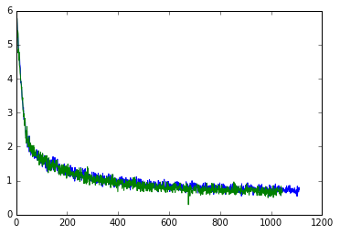

```
'\nl_a= load_obj("DATA/loss_track_a")\nl_b= load_obj("DATA/loss_track_b")\nl_c= load_obj("DATA/loss_track_c")\nl_58= load_obj("DATA/loss_track_58")\nl_59= load_obj("DATA/loss_track_59")\nl_61= load_obj("DATA/loss_track_61")\nl_62= load_obj("DATA/loss_track_62")\nwhile len(l_c)< len(l_b):\n    l_c.ap…
```

```python
import matplotlib.pyplot as plt
from matplotlib.font_manager import FontProperties
from utils import *
plt.figure()
l_a= load_obj("fp_06_data/loss_track8")
l_b= load_obj("fp_02_data/loss_track8")
print len(l_a), len(l_b)
plt.plot(l_a)
plt.plot(l_b)
plt.ylim(0,6)
plt.show()
#l_c= load_obj("DATA/loss_track_c")
"""
l_a= load_obj("DATA/loss_track_a")
l_b= load_obj("DATA/loss_track_b")
l_c= load_obj("DATA/loss_track_c")
l_58= load_obj("DATA/loss_track_58")
l_59= load_obj("DATA/loss_track_59")
l_61= load_obj("DATA/loss_track_61")
l_62= load_obj("DATA/loss_track_62")
while len(l_c)< len(l_b):
    l_c.append(0)
#l_128
batches = 35000/51
ticks = [(batches*i, i) for i in range(1,51)]
fig = plt.figure()

plt.plot(30*np.arange(0,len(l_c)),l_c, label='$P_f=0$')
#plt.
fig = plt.figure()
T = 100*np.arange(0,len(l_58))
plt.plot(30*np.arange(0,len(l_a)),l_a, label='$P_f=1$' )
plt.plot(30*np.arange(0,len(l_b)),l_b, label='$P_f=0.5$')
plt.plot(T,l_62, label=r"$P_f=0.2$")
plt.plot(30*np.arange(0,len(l_c)),l_c, label='$P_f=0$')
plt.plot(T,l_58, label=r"$N_h=512$ annealed")
plt.plot(T,l_59, label=r"$N_h=256$ annealed")

#plt.plot(T,l_61, label=r"$N_h=256$, $P_f=0.2$")

plt.legend(loc='upper center', bbox_to_anchor=(0.5, 1.25),
          ncol=3, fancybox=True, shadow=True)
plt.ylabel('Batch Loss')
plt.xlabel('Batch Number')
plt.xlim(0,35000)
plt.ylim(0,6)
plt.show()
"""
```

```python
preds_BM, targs_BM = load_obj("DATA/BM_translated_test"), load_obj("DATA/BM_target")
print len(preds_BM)
```

```
24911
```

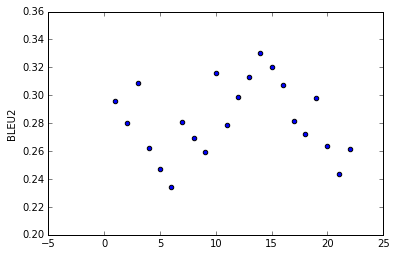

```
NMT Corpus BLEU4: 0.00750688655243 	 BLEU2: 0.0609424657418 	 BLEU1: 0.186971357143

1085
```

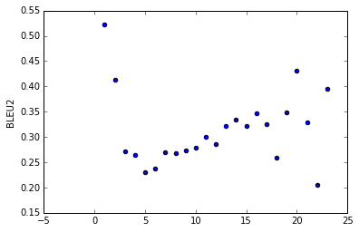

```
NMT Corpus BLEU4: 0.0051306783277 	 BLEU2: 0.0573189823353 	 BLEU1: 0.194453530706
```

```
(0.19445353070615168, 0.057318982335335944, 0.005130678327700388)
```

```python
import matplotlib.pyplot as plt

def BLEU_analysis(preds, targs, Ngram_len = 2, lab="NMT"):
    bleu = dict()
    for p, a in zip(preds, targs):
        BLEU4 = bleu_score.corpus_bleu([a], [p], weights=(0.25,0.25, 0.25,0.25))
        BLEU2 = bleu_score.corpus_bleu([a], [p], weights=(0.5,0.5))
        BLEU1 = bleu_score.corpus_bleu([a], [p], weights=([1]))
        l = len(p)
        if l not in bleu.keys():
            bleu[l] = []
        bleu[l].append(eval("BLEU"+str(Ngram_len)))
    BLEU4 = bleu_score.corpus_bleu(targs, preds, weights=(0.25,0.25, 0.25,0.25))
    BLEU2 = bleu_score.corpus_bleu(targs, preds, weights=(0.5,0.5))
    BLEU1 = bleu_score.corpus_bleu(targs, preds, weights=([1]))
    bleu_mean = [np.mean(v) for v in bleu.values()]
    plt.figure()
    X = range(1,max(bleu.keys())+1)
    plt.scatter(X, bleu_mean)
    plt.ylabel("BLEU"+str(Ngram_len))
    plt.show()
    print'{} Corpus BLEU4: {} \t BLEU2: {} \t BLEU1: {}\n'.format(lab, BLEU4, BLEU2, BLEU1)
    return BLEU1, BLEU2, BLEU4


nmt_02_data = load_obj("fp_02_data/PREDICTIONS8")
preds, targs = nmt_02_data[0], nmt_02_data[1]
BLEU_analysis(preds, targs)
print len(preds)

nmt_06_data = load_obj("fp_06_data/PREDICTIONS8")
preds, targs = nmt_06_data[0], nmt_06_data[1]
BLEU_analysis(preds, targs)
```

```python
BLEU_analysis(preds_BM, targs_BM)
```

[output not shown]

# Results

With a `feed_previous` probability of 0.7, where 70% of the decoder inputs are previously generated tokens, after only around 6 epochs the model is making predictions which are more accurate than some of the data, for example:

```
Source: scrutin du jour du lendemain le h 9
actual: there is a tie or difference between first 2 candidates is less than 10 votes -
predicted:  9 are no day in a between the day months
```

where the English translation is is totally incorrect and is obviously just some error in the dataset, however the NMT prediction is in the right ball-park. The google translate answer is "9:00 am the day after polling day".

After 12 epochs, the model makes predictions with a very similar meaning to the correct translation but expressed differently

```
Actual: some 15 of the park's native mammal species are considered rare threatened or endangered
predicted: several of percent the species's marine mammal species are rare threatened or or endangered
```